# Credit EDA Case Study

### Bivariate Analysis where 'TARGET' = 1

```python
# Defining a function to view bivariate analysis between categorical and continous variable
def plotCatNum(df, catColName, numColName):
    '''
    This function is used to plot to bivariate analysis between categorical and continous variable
    @df (dataframe) - Dataframe for which frequency table is to be plotted
    @catColName (string) - Column name of categorical variable for which frequency table is to be plotted
    @numColName (string) - Column name of continous variable for which frequency table is to be plotted
    '''
    sns.barplot(x=catColName,y=numColName,data=df)
    plt.title(catColName +' vs '+ numColName)
    plt.xticks(rotation = 90)
    plt.show();
```

```python
# Defining a function to view bivariate analysis between continous variables
def plotNumNum(df, num1ColName, num2ColName):
    '''
    This function is used to plot to bivariate analysis between two continous variable
    @df (dataframe) - Dataframe for which frequency table is to be plotted
    @catColName (string) - Column name of first continous variable for which frequency table is to be plotted
    @numColName (string) - Column name of second continous variable for which frequency table is to be plotted
    '''
    sns.set(style="whitegrid")
    plt.figure(figsize=(20,5))
    plt.title(num1ColName +' vs '+ num2ColName)
    plt.xticks(rotation = 90)
    sns.pointplot(x=num1ColName,y=num2ColName,data=df)
    plt.show();
```

#### Analysis of Education Type versus Loan Annuity

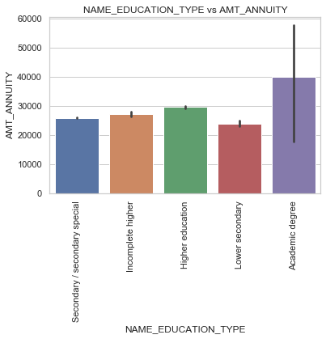

```python
plotCatNum(dfOne,'NAME_EDUCATION_TYPE','AMT_ANNUITY')
```

**Findings:** Here we can observe that most of the clients with Academic Degree has the highest mean amount of loan annuity followed by clients that completed Higher education

#### Analysis of Family Status versus Loan Credit Amount

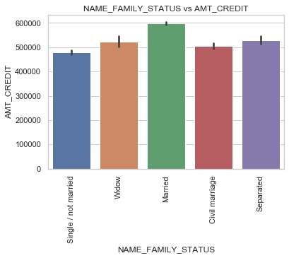

```python
plotCatNum(dfOne,'NAME_FAMILY_STATUS','AMT_CREDIT')
```

#### Analysis of Income type versus Loan Credit Amount

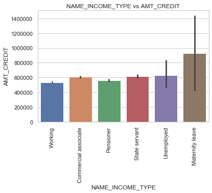

```python
plotCatNum(dfOne,'NAME_INCOME_TYPE','AMT_CREDIT')
```

**Findings:** Here we can observe that most of the clients that are on maternity leave have the highest credit amount followed by Unemployed and State servant clients

#### Analysis of Housing status versus Loan Annuity

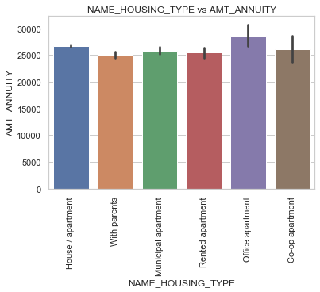

```python
plotCatNum(dfOne,'NAME_HOUSING_TYPE','AMT_ANNUITY')
```

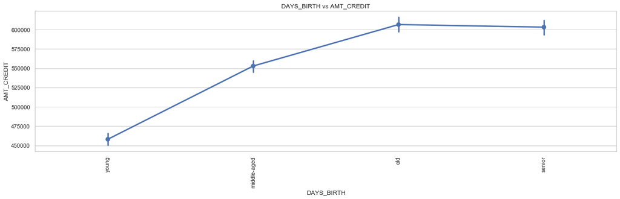

```python
plotNumNum(dfOne,'DAYS_BIRTH','AMT_CREDIT')
```

**Findings:** Here we can observe that most of the clients that are old has the highest credit loan amount followed by senior citizens

### Bivariate Analysis where 'TARGET' = 0

#### Analysis of Education Type versus Loan Annuity

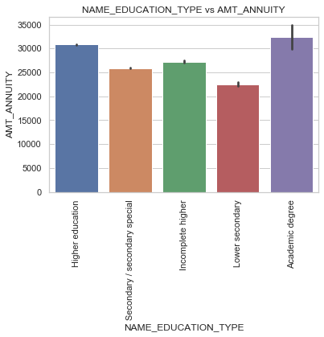

```python
plotCatNum(dfZero,'NAME_EDUCATION_TYPE','AMT_ANNUITY')
```

**Findings:** Here we can observe that most of the clients with Academic Degree has the highest mean amount of loan annuity followed by clients that completed Higher education

#### Analysis of Family Status versus Loan Credit Amount

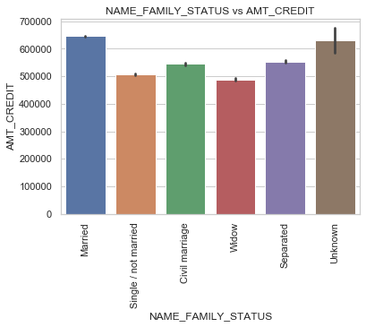

```python
plotCatNum(dfZero,'NAME_FAMILY_STATUS','AMT_CREDIT')
```

**Findings:** Here we can observe that most of the clients that are married have the highest credit amount followed by clients that are unwilling to share their family status

#### Analysis of Income type versus Loan Credit Amount

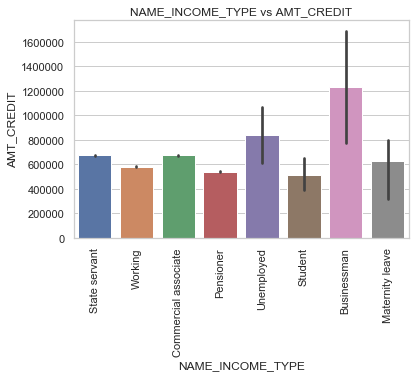

```python
plotCatNum(dfZero,'NAME_INCOME_TYPE','AMT_CREDIT')
```

#### Analysis of Housing status versus Loan Annuity

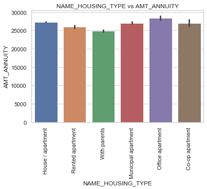

```python
plotCatNum(dfZero,'NAME_HOUSING_TYPE','AMT_ANNUITY')
```

**Findings:** Here we can observe that most of the clients that live in office provided apartment have the highest loaan annuity followed by Co-op apartment and Municipal apartment

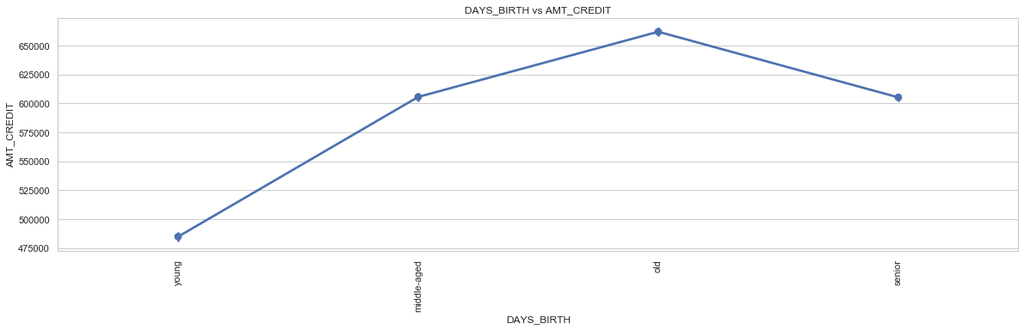

```python
plotNumNum(dfZero,'DAYS_BIRTH','AMT_CREDIT')
```

**Findings:** Here we can observe that most of the clients that are old has the highest credit loan amount followed by senior citizens

## EDA of Previous Application

For previous data we are going to perform sense check and carry on with the analysis

### Sense Check of the data

```python
# Checking the top 5 rows and headers of the data
previousData.head()
```

|  | SK_ID_PREV | SK_ID_CURR | NAME_CONTRACT_TYPE | AMT_ANNUITY | AMT_APPLICATION | AMT_CREDIT | AMT_DOWN_PAYMENT | AMT_GOODS_PRICE | WEEKDAY_APPR_PROCESS_START | HOUR_APPR_PROCESS_START | FLAG_LAST_APPL_PER_CONTRACT | NFLAG_LAST_APPL_IN_DAY | RATE_DOWN_PAYMENT | RATE_INTEREST_PRIMARY | RATE_INTEREST_PRIVILEGED | NAME_CASH_LOAN_PURPOSE | NAME_CONTRACT_STATUS | DAYS_DECISION | NAME_PAYMENT_TYPE | CODE_REJECT_REASON | NAME_TYPE_SUITE | NAME_CLIENT_TYPE | NAME_GOODS_CATEGORY | NAME_PORTFOLIO | NAME_PRODUCT_TYPE | CHANNEL_TYPE | SELLERPLACE_AREA | NAME_SELLER_INDUSTRY | CNT_PAYMENT | … |
| --- | --- | --- | --- | --- | --- | --- | --- | --- | --- | --- | --- | --- | --- | --- | --- | --- | --- | --- | --- | --- | --- | --- | --- | --- | --- | --- | --- | --- | --- | --- |
| 0 | 2030495 | 271877 | Consumer loans | 1730.430 | 17145.0 | 17145.0 | 0.0 | 17145.0 | SATURDAY | 15 | Y | 1 | 0.0 | 0.182832 | 0.867336 | XAP | Approved | -73 | Cash through the bank | XAP | NaN | Repeater | Mobile | POS | XNA | Country-wide | 35 | Connectivity | 12.0 | … |
| 1 | 2802425 | 108129 | Cash loans | 25188.615 | 607500.0 | 679671.0 | NaN | 607500.0 | THURSDAY | 11 | Y | 1 | NaN | NaN | NaN | XNA | Approved | -164 | XNA | XAP | Unaccompanied | Repeater | XNA | Cash | x-sell | Contact center | -1 | XNA | 36.0 | … |
| 2 | 2523466 | 122040 | Cash loans | 15060.735 | 112500.0 | 136444.5 | NaN | 112500.0 | TUESDAY | 11 | Y | 1 | NaN | NaN | NaN | XNA | Approved | -301 | Cash through the bank | XAP | Spouse, partner | Repeater | XNA | Cash | x-sell | Credit and cash offices | -1 | XNA | 12.0 | … |
| 3 | 2819243 | 176158 | Cash loans | 47041.335 | 450000.0 | 470790.0 | NaN | 450000.0 | MONDAY | 7 | Y | 1 | NaN | NaN | NaN | XNA | Approved | -512 | Cash through the bank | XAP | NaN | Repeater | XNA | Cash | x-sell | Credit and cash offices | -1 | XNA | 12.0 | … |
| 4 | 1784265 | 202054 | Cash loans | 31924.395 | 337500.0 | 404055.0 | NaN | 337500.0 | THURSDAY | 9 | Y | 1 | NaN | NaN | NaN | Repairs | Refused | -781 | Cash through the bank | HC | NaN | Repeater | XNA | Cash | walk-in | Credit and cash offices | -1 | XNA | 24.0 | … |

```python
# Looking at the type fo the data frame, data types and the number of rows
previousData.info()
```

```
<class 'pandas.core.frame.DataFrame'>
RangeIndex: 1670214 entries, 0 to 1670213
Data columns (total 37 columns):
SK_ID_PREV                     1670214 non-null int64
SK_ID_CURR                     1670214 non-null int64
NAME_CONTRACT_TYPE             1670214 non-null object
AMT_ANNUITY                    1297979 non-null float64
AMT_APPLICATION                1670214 non-null float64
AMT_CREDIT                     1670213 non-null float64
AMT_DOWN_PAYMENT               774370 non-null float64
AMT_GOODS_PRICE                1284699 non-null float64
WEEKDAY_APPR_PROCESS_START     1670214 non-null object
HOUR_APPR_PROCESS_START        1670214 non-null int64
FLAG_LAST_APPL_PER_CONTRACT    1670214 non-null object
NFLAG_LAST_APPL_IN_DAY         1670214 non-null int64
RATE_DOWN_PAYMENT              774370 non-null float64
RATE_INTEREST_PRIMARY          5951 non-null float64
RATE_INTEREST_PRIVILEGED       5951 non-null float64
NAME_CASH_LOAN_PURPOSE         1670214 non-null object
NAME_CONTRACT_STATUS           1670214 non-null object
DAYS_DECISION                  1670214 non-null int64
NAME_PAYMENT_TYPE              1670214 non-null object
CODE_REJECT_REASON             1670214 non-null object
NAME_TYPE_SUITE                849809 non-null object
NAME_CLIENT_TYPE               1670214 non-null object
NAME_GOODS_CATEGORY            1670214 non-null object
NAME_PORTFOLIO                 1670214 non-null object
NAME_PRODUCT_TYPE              1670214 non-null object
CHANNEL_TYPE                   1670214 non-null object
SELLERPLACE_AREA               1670214 non-null int64
NAME_SELLER_INDUSTRY           1670214 non-null object
CNT_PAYMENT                    1297984 non-null float64
NAME_YIELD_GROUP               1670214 non-null object
PRODUCT_COMBINATION            1669868 non-null object
DAYS_FIRST_DRAWING             997149 non-null float64
DAYS_FIRST_DUE                 997149 non-null float64
DAYS_LAST_DUE_1ST_VERSION      997149 non-null float64
DAYS_LAST_DUE                  997149 non-null float64
DAYS_TERMINATION               997149 non-null float64
NFLAG_INSURED_ON_APPROVAL      997149 non-null float64
dtypes: float64(15), int64(6), object(16)
memory usage: 471.5+ MB
```

```python
# Checking the number of rows and columns present in the data
previousData.shape
```

```
(1670214, 37)
```

```python
# Looking at the data types of the data
previousData.dtypes.head()
```

```
SK_ID_PREV              int64
SK_ID_CURR              int64
NAME_CONTRACT_TYPE     object
AMT_ANNUITY           float64
AMT_APPLICATION       float64
dtype: object
```

```python
# Making a copy of the application in dataframe df (checkpoint!)
dfPrev = previousData.copy(deep=False)
```

```python
# Calculating the percent of missing values in the dataframe
percentMissingPrev = (dfPrev.isnull().sum() / len(dfPrev)) * 100

# Making a dataframe with the missing values % and columns into a dataframe (on account of large number of rows)
missingValuesDfPrev = pd.DataFrame({'columnName': dfPrev.columns,
                                 'percentMissingPrev': percentMissingPrev})
```

```python
# Viewing the dataframe to ensure that the values have been populated correctly
missingValuesDfPrev.head()
```

|  | columnName | percentMissingPrev |
| --- | --- | --- |
| SK_ID_PREV | SK_ID_PREV | 0.000000 |
| SK_ID_CURR | SK_ID_CURR | 0.000000 |
| NAME_CONTRACT_TYPE | NAME_CONTRACT_TYPE | 0.000000 |
| AMT_ANNUITY | AMT_ANNUITY | 22.286665 |
| AMT_APPLICATION | AMT_APPLICATION | 0.000000 |

```python
# Viewing the columns that have more than 10% of missing data
missingValuesDfPrev.loc[missingValuesDfPrev['percentMissingPrev'] > 10].head()
```

|  | columnName | percentMissingPrev |
| --- | --- | --- |
| AMT_ANNUITY | AMT_ANNUITY | 22.286665 |
| AMT_DOWN_PAYMENT | AMT_DOWN_PAYMENT | 53.636480 |
| AMT_GOODS_PRICE | AMT_GOODS_PRICE | 23.081773 |
| RATE_DOWN_PAYMENT | RATE_DOWN_PAYMENT | 53.636480 |
| RATE_INTEREST_PRIMARY | RATE_INTEREST_PRIMARY | 99.643698 |

```python
missingValuesDfPrev.loc[missingValuesDfPrev['percentMissingPrev'] > 10].shape
```

```
(14, 2)
```

Here, we notice that there are 14 column of the original 37 columns that have more than 10% missing values.

So, we shall have 23 columns in the modified dataset

```python
# Obtaining the columns with more than 10% missing data
columnsWithMissingValuesPrev = missingValuesDfPrev.loc[missingValuesDfPrev['percentMissingPrev'] > 10]
missingColumnsPrev = columnsWithMissingValuesPrev['columnName'].reset_index(drop=True).tolist()
```

```python
# Droppping the columns with more than 10% missing values from the original dataset
dfPrev.drop(missingColumnsPrev, axis=1, inplace=True)
```

```python
# Looking at the shape of the modified data
dfPrev.shape
```

```
(1670214, 23)
```

```python
df.shape
```

```
(307511, 65)
```

```python
# Viewing the head of the data
dfPrev.head()
```

|  | SK_ID_PREV | SK_ID_CURR | NAME_CONTRACT_TYPE | AMT_APPLICATION | AMT_CREDIT | WEEKDAY_APPR_PROCESS_START | HOUR_APPR_PROCESS_START | FLAG_LAST_APPL_PER_CONTRACT | NFLAG_LAST_APPL_IN_DAY | NAME_CASH_LOAN_PURPOSE | NAME_CONTRACT_STATUS | DAYS_DECISION | NAME_PAYMENT_TYPE | CODE_REJECT_REASON | NAME_CLIENT_TYPE | NAME_GOODS_CATEGORY | NAME_PORTFOLIO | NAME_PRODUCT_TYPE | CHANNEL_TYPE | SELLERPLACE_AREA | NAME_SELLER_INDUSTRY | NAME_YIELD_GROUP | PRODUCT_COMBINATION |
| --- | --- | --- | --- | --- | --- | --- | --- | --- | --- | --- | --- | --- | --- | --- | --- | --- | --- | --- | --- | --- | --- | --- | --- |
| 0 | 2030495 | 271877 | Consumer loans | 17145.0 | 17145.0 | SATURDAY | 15 | Y | 1 | XAP | Approved | -73 | Cash through the bank | XAP | Repeater | Mobile | POS | XNA | Country-wide | 35 | Connectivity | middle | POS mobile with interest |
| 1 | 2802425 | 108129 | Cash loans | 607500.0 | 679671.0 | THURSDAY | 11 | Y | 1 | XNA | Approved | -164 | XNA | XAP | Repeater | XNA | Cash | x-sell | Contact center | -1 | XNA | low_action | Cash X-Sell: low |
| 2 | 2523466 | 122040 | Cash loans | 112500.0 | 136444.5 | TUESDAY | 11 | Y | 1 | XNA | Approved | -301 | Cash through the bank | XAP | Repeater | XNA | Cash | x-sell | Credit and cash offices | -1 | XNA | high | Cash X-Sell: high |
| 3 | 2819243 | 176158 | Cash loans | 450000.0 | 470790.0 | MONDAY | 7 | Y | 1 | XNA | Approved | -512 | Cash through the bank | XAP | Repeater | XNA | Cash | x-sell | Credit and cash offices | -1 | XNA | middle | Cash X-Sell: middle |
| 4 | 1784265 | 202054 | Cash loans | 337500.0 | 404055.0 | THURSDAY | 9 | Y | 1 | Repairs | Refused | -781 | Cash through the bank | HC | Repeater | XNA | Cash | walk-in | Credit and cash offices | -1 | XNA | high | Cash Street: high |

## Merging Previous and application Data for analysis

```python
## Adding back the states column
dfMerged = pd.merge(dfPrev, df,on = ['SK_ID_CURR'],  how='left')
dfMerged.head(10)
```

|  | SK_ID_PREV | SK_ID_CURR | NAME_CONTRACT_TYPE_x | AMT_APPLICATION | AMT_CREDIT_x | WEEKDAY_APPR_PROCESS_START_x | HOUR_APPR_PROCESS_START_x | FLAG_LAST_APPL_PER_CONTRACT | NFLAG_LAST_APPL_IN_DAY | NAME_CASH_LOAN_PURPOSE | NAME_CONTRACT_STATUS | DAYS_DECISION | NAME_PAYMENT_TYPE | CODE_REJECT_REASON | NAME_CLIENT_TYPE | NAME_GOODS_CATEGORY | NAME_PORTFOLIO | NAME_PRODUCT_TYPE | CHANNEL_TYPE | SELLERPLACE_AREA | NAME_SELLER_INDUSTRY | NAME_YIELD_GROUP | PRODUCT_COMBINATION | TARGET | NAME_CONTRACT_TYPE_y | CODE_GENDER | FLAG_OWN_CAR | FLAG_OWN_REALTY | CNT_CHILDREN | … |
| --- | --- | --- | --- | --- | --- | --- | --- | --- | --- | --- | --- | --- | --- | --- | --- | --- | --- | --- | --- | --- | --- | --- | --- | --- | --- | --- | --- | --- | --- | --- |
| 0 | 2030495 | 271877 | Consumer loans | 17145.0 | 17145.0 | SATURDAY | 15 | Y | 1 | XAP | Approved | -73 | Cash through the bank | XAP | Repeater | Mobile | POS | XNA | Country-wide | 35 | Connectivity | middle | POS mobile with interest | 0.0 | Cash loans | F | N | Y | 1.0 | … |
| 1 | 2802425 | 108129 | Cash loans | 607500.0 | 679671.0 | THURSDAY | 11 | Y | 1 | XNA | Approved | -164 | XNA | XAP | Repeater | XNA | Cash | x-sell | Contact center | -1 | XNA | low_action | Cash X-Sell: low | 0.0 | Revolving loans | F | N | N | 0.0 | … |
| 2 | 2523466 | 122040 | Cash loans | 112500.0 | 136444.5 | TUESDAY | 11 | Y | 1 | XNA | Approved | -301 | Cash through the bank | XAP | Repeater | XNA | Cash | x-sell | Credit and cash offices | -1 | XNA | high | Cash X-Sell: high | 0.0 | Cash loans | F | N | Y | 3.0 | … |
| 3 | 2819243 | 176158 | Cash loans | 450000.0 | 470790.0 | MONDAY | 7 | Y | 1 | XNA | Approved | -512 | Cash through the bank | XAP | Repeater | XNA | Cash | x-sell | Credit and cash offices | -1 | XNA | middle | Cash X-Sell: middle | 0.0 | Cash loans | M | Y | Y | 0.0 | … |
| 4 | 1784265 | 202054 | Cash loans | 337500.0 | 404055.0 | THURSDAY | 9 | Y | 1 | Repairs | Refused | -781 | Cash through the bank | HC | Repeater | XNA | Cash | walk-in | Credit and cash offices | -1 | XNA | high | Cash Street: high | 0.0 | Cash loans | F | N | N | 1.0 | … |
| 5 | 1383531 | 199383 | Cash loans | 315000.0 | 340573.5 | SATURDAY | 8 | Y | 1 | Everyday expenses | Approved | -684 | Cash through the bank | XAP | Repeater | XNA | Cash | x-sell | Credit and cash offices | -1 | XNA | low_normal | Cash X-Sell: low | 0.0 | Cash loans | M | Y | Y | 0.0 | … |
| 6 | 2315218 | 175704 | Cash loans | 0.0 | 0.0 | TUESDAY | 11 | Y | 1 | XNA | Canceled | -14 | XNA | XAP | Repeater | XNA | XNA | XNA | Credit and cash offices | -1 | XNA | XNA | Cash | 0.0 | Cash loans | F | N | Y | 0.0 | … |
| 7 | 1656711 | 296299 | Cash loans | 0.0 | 0.0 | MONDAY | 7 | Y | 1 | XNA | Canceled | -21 | XNA | XAP | Repeater | XNA | XNA | XNA | Credit and cash offices | -1 | XNA | XNA | Cash | 0.0 | Cash loans | F | N | Y | 0.0 | … |
| 8 | 2367563 | 342292 | Cash loans | 0.0 | 0.0 | MONDAY | 15 | Y | 1 | XNA | Canceled | -386 | XNA | XAP | Repeater | XNA | XNA | XNA | Credit and cash offices | -1 | XNA | XNA | Cash | 0.0 | Cash loans | F | N | N | 0.0 | … |
| 9 | 2579447 | 334349 | Cash loans | 0.0 | 0.0 | SATURDAY | 15 | Y | 1 | XNA | Canceled | -57 | XNA | XAP | Repeater | XNA | XNA | XNA | Credit and cash offices | -1 | XNA | XNA | Cash | 0.0 | Cash loans | F | N | N | 0.0 | … |

```python
## Describing the merged data
dfMerged.info()
```

```
<class 'pandas.core.frame.DataFrame'>
Int64Index: 1670214 entries, 0 to 1670213
Data columns (total 87 columns):
SK_ID_PREV                      1670214 non-null int64
SK_ID_CURR                      1670214 non-null int64
NAME_CONTRACT_TYPE_x            1670214 non-null object
AMT_APPLICATION                 1670214 non-null float64
AMT_CREDIT_x                    1670213 non-null float64
WEEKDAY_APPR_PROCESS_START_x    1670214 non-null object
HOUR_APPR_PROCESS_START_x       1670214 non-null int64
FLAG_LAST_APPL_PER_CONTRACT     1670214 non-null object
NFLAG_LAST_APPL_IN_DAY          1670214 non-null int64
NAME_CASH_LOAN_PURPOSE          1670214 non-null object
NAME_CONTRACT_STATUS            1670214 non-null object
DAYS_DECISION                   1670214 non-null int64
NAME_PAYMENT_TYPE               1670214 non-null object
CODE_REJECT_REASON              1670214 non-null object
NAME_CLIENT_TYPE                1670214 non-null object
NAME_GOODS_CATEGORY             1670214 non-null object
NAME_PORTFOLIO                  1670214 non-null object
NAME_PRODUCT_TYPE               1670214 non-null object
CHANNEL_TYPE                    1670214 non-null object
SELLERPLACE_AREA                1670214 non-null int64
NAME_SELLER_INDUSTRY            1670214 non-null object
NAME_YIELD_GROUP                1670214 non-null object
PRODUCT_COMBINATION             1669868 non-null object
TARGET                          1413701 non-null float64
NAME_CONTRACT_TYPE_y            1413701 non-null object
CODE_GENDER                     1413701 non-null object
FLAG_OWN_CAR                    1413701 non-null object
FLAG_OWN_REALTY                 1413701 non-null object
CNT_CHILDREN                    1413701 non-null float64
AMT_INCOME_TOTAL                1413701 non-null float64
AMT_CREDIT_y                    1413701 non-null float64
AMT_ANNUITY                     1413608 non-null float64
AMT_GOODS_PRICE                 1412493 non-null float64
NAME_TYPE_SUITE                 1410175 non-null object
NAME_INCOME_TYPE                1413701 non-null object
NAME_EDUCATION_TYPE             1413701 non-null object
NAME_FAMILY_STATUS              1413701 non-null object
```

[output cut: 37 more lines]

```
FLAG_DOCUMENT_9                 1413701 non-null float64
FLAG_DOCUMENT_10                1413701 non-null float64
FLAG_DOCUMENT_11                1413701 non-null float64
FLAG_DOCUMENT_12                1413701 non-null float64
FLAG_DOCUMENT_13                1413701 non-null float64
FLAG_DOCUMENT_14                1413701 non-null float64
FLAG_DOCUMENT_15                1413701 non-null float64
FLAG_DOCUMENT_16                1413701 non-null float64
FLAG_DOCUMENT_17                1413701 non-null float64
FLAG_DOCUMENT_18                1413701 non-null float64
FLAG_DOCUMENT_19                1413701 non-null float64
FLAG_DOCUMENT_20                1413701 non-null float64
FLAG_DOCUMENT_21                1413701 non-null float64
dtypes: category(2), float64(53), int64(6), object(26)
memory usage: 1.1+ GB
```

### Subsetting the merged data based on Target Variable

```python
# Subsetting the data where target = 1
dfPrevOne = dfMerged[dfMerged['TARGET'] > 0]
```

```python
# Doing a sense check of the data
dfPrevOne.shape
```

```
(122360, 87)
```

```python
# Viewing the data
dfPrevOne.head()
```

|  | SK_ID_PREV | SK_ID_CURR | NAME_CONTRACT_TYPE_x | AMT_APPLICATION | AMT_CREDIT_x | WEEKDAY_APPR_PROCESS_START_x | HOUR_APPR_PROCESS_START_x | FLAG_LAST_APPL_PER_CONTRACT | NFLAG_LAST_APPL_IN_DAY | NAME_CASH_LOAN_PURPOSE | NAME_CONTRACT_STATUS | DAYS_DECISION | NAME_PAYMENT_TYPE | CODE_REJECT_REASON | NAME_CLIENT_TYPE | NAME_GOODS_CATEGORY | NAME_PORTFOLIO | NAME_PRODUCT_TYPE | CHANNEL_TYPE | SELLERPLACE_AREA | NAME_SELLER_INDUSTRY | NAME_YIELD_GROUP | PRODUCT_COMBINATION | TARGET | NAME_CONTRACT_TYPE_y | CODE_GENDER | FLAG_OWN_CAR | FLAG_OWN_REALTY | CNT_CHILDREN | … |
| --- | --- | --- | --- | --- | --- | --- | --- | --- | --- | --- | --- | --- | --- | --- | --- | --- | --- | --- | --- | --- | --- | --- | --- | --- | --- | --- | --- | --- | --- | --- |
| 27 | 1676258 | 433469 | Cash loans | 247500.0 | 268083.0 | THURSDAY | 14 | Y | 1 | XNA | Approved | -1883 | XNA | XAP | Repeater | XNA | Cash | x-sell | Country-wide | -1 | Consumer electronics | high | Cash X-Sell: high | 1.0 | Cash loans | F | Y | N | 0.0 | … |
| 52 | 1912041 | 253391 | Cash loans | 45000.0 | 47970.0 | SUNDAY | 17 | Y | 1 | XNA | Refused | -774 | Cash through the bank | HC | Refreshed | XNA | Cash | x-sell | Regional / Local | 333 | Consumer electronics | high | Cash X-Sell: high | 1.0 | Cash loans | F | N | Y | 0.0 | … |
| 58 | 1760006 | 283527 | Cash loans | 72000.0 | 72000.0 | WEDNESDAY | 15 | Y | 1 | XNA | Approved | -183 | XNA | XAP | Repeater | XNA | Cash | x-sell | Contact center | -1 | XNA | high | Cash X-Sell: high | 1.0 | Cash loans | M | N | N | 0.0 | … |
| 63 | 1074341 | 137179 | Cash loans | 0.0 | 0.0 | FRIDAY | 16 | Y | 1 | XNA | Canceled | -237 | XNA | XAP | Repeater | XNA | XNA | XNA | Credit and cash offices | -1 | XNA | XNA | Cash | 1.0 | Cash loans | F | N | N | 0.0 | … |
| 94 | 2408628 | 320444 | Cash loans | 1035000.0 | 1110141.0 | FRIDAY | 16 | Y | 1 | XNA | Approved | -953 | Cash through the bank | XAP | Repeater | XNA | Cash | x-sell | Credit and cash offices | -1 | XNA | middle | Cash X-Sell: middle | 1.0 | Cash loans | F | Y | Y | 0.0 | … |

```python
# Subsetting the data where target = 0
dfPrevZero = dfMerged[dfMerged['TARGET'] < 1]
```

```python
# Doing a sense check of the data
dfPrevZero.shape
```

```
(1291341, 87)
```

```python
# Viewing the data
dfPrevZero.head()
```

|  | SK_ID_PREV | SK_ID_CURR | NAME_CONTRACT_TYPE_x | AMT_APPLICATION | AMT_CREDIT_x | WEEKDAY_APPR_PROCESS_START_x | HOUR_APPR_PROCESS_START_x | FLAG_LAST_APPL_PER_CONTRACT | NFLAG_LAST_APPL_IN_DAY | NAME_CASH_LOAN_PURPOSE | NAME_CONTRACT_STATUS | DAYS_DECISION | NAME_PAYMENT_TYPE | CODE_REJECT_REASON | NAME_CLIENT_TYPE | NAME_GOODS_CATEGORY | NAME_PORTFOLIO | NAME_PRODUCT_TYPE | CHANNEL_TYPE | SELLERPLACE_AREA | NAME_SELLER_INDUSTRY | NAME_YIELD_GROUP | PRODUCT_COMBINATION | TARGET | NAME_CONTRACT_TYPE_y | CODE_GENDER | FLAG_OWN_CAR | FLAG_OWN_REALTY | CNT_CHILDREN | … |
| --- | --- | --- | --- | --- | --- | --- | --- | --- | --- | --- | --- | --- | --- | --- | --- | --- | --- | --- | --- | --- | --- | --- | --- | --- | --- | --- | --- | --- | --- | --- |
| 0 | 2030495 | 271877 | Consumer loans | 17145.0 | 17145.0 | SATURDAY | 15 | Y | 1 | XAP | Approved | -73 | Cash through the bank | XAP | Repeater | Mobile | POS | XNA | Country-wide | 35 | Connectivity | middle | POS mobile with interest | 0.0 | Cash loans | F | N | Y | 1.0 | … |
| 1 | 2802425 | 108129 | Cash loans | 607500.0 | 679671.0 | THURSDAY | 11 | Y | 1 | XNA | Approved | -164 | XNA | XAP | Repeater | XNA | Cash | x-sell | Contact center | -1 | XNA | low_action | Cash X-Sell: low | 0.0 | Revolving loans | F | N | N | 0.0 | … |
| 2 | 2523466 | 122040 | Cash loans | 112500.0 | 136444.5 | TUESDAY | 11 | Y | 1 | XNA | Approved | -301 | Cash through the bank | XAP | Repeater | XNA | Cash | x-sell | Credit and cash offices | -1 | XNA | high | Cash X-Sell: high | 0.0 | Cash loans | F | N | Y | 3.0 | … |
| 3 | 2819243 | 176158 | Cash loans | 450000.0 | 470790.0 | MONDAY | 7 | Y | 1 | XNA | Approved | -512 | Cash through the bank | XAP | Repeater | XNA | Cash | x-sell | Credit and cash offices | -1 | XNA | middle | Cash X-Sell: middle | 0.0 | Cash loans | M | Y | Y | 0.0 | … |
| 4 | 1784265 | 202054 | Cash loans | 337500.0 | 404055.0 | THURSDAY | 9 | Y | 1 | Repairs | Refused | -781 | Cash through the bank | HC | Repeater | XNA | Cash | walk-in | Credit and cash offices | -1 | XNA | high | Cash Street: high | 0.0 | Cash loans | F | N | N | 1.0 | … |

### Univariate Analysis on previous data where 'TARGET' = 1

Here, we are doing univariate analysis for dfPrevOne and dfPrevZero separately. We shall do this for numerical as well as categorical variables.

#### Univariate Analysis for numerical variables

```python
# Sense check of data
dfPrevOne.head()
```

|  | SK_ID_PREV | SK_ID_CURR | NAME_CONTRACT_TYPE_x | AMT_APPLICATION | AMT_CREDIT_x | WEEKDAY_APPR_PROCESS_START_x | HOUR_APPR_PROCESS_START_x | FLAG_LAST_APPL_PER_CONTRACT | NFLAG_LAST_APPL_IN_DAY | NAME_CASH_LOAN_PURPOSE | NAME_CONTRACT_STATUS | DAYS_DECISION | NAME_PAYMENT_TYPE | CODE_REJECT_REASON | NAME_CLIENT_TYPE | NAME_GOODS_CATEGORY | NAME_PORTFOLIO | NAME_PRODUCT_TYPE | CHANNEL_TYPE | SELLERPLACE_AREA | NAME_SELLER_INDUSTRY | NAME_YIELD_GROUP | PRODUCT_COMBINATION | TARGET | NAME_CONTRACT_TYPE_y | CODE_GENDER | FLAG_OWN_CAR | FLAG_OWN_REALTY | CNT_CHILDREN | … |
| --- | --- | --- | --- | --- | --- | --- | --- | --- | --- | --- | --- | --- | --- | --- | --- | --- | --- | --- | --- | --- | --- | --- | --- | --- | --- | --- | --- | --- | --- | --- |
| 27 | 1676258 | 433469 | Cash loans | 247500.0 | 268083.0 | THURSDAY | 14 | Y | 1 | XNA | Approved | -1883 | XNA | XAP | Repeater | XNA | Cash | x-sell | Country-wide | -1 | Consumer electronics | high | Cash X-Sell: high | 1.0 | Cash loans | F | Y | N | 0.0 | … |
| 52 | 1912041 | 253391 | Cash loans | 45000.0 | 47970.0 | SUNDAY | 17 | Y | 1 | XNA | Refused | -774 | Cash through the bank | HC | Refreshed | XNA | Cash | x-sell | Regional / Local | 333 | Consumer electronics | high | Cash X-Sell: high | 1.0 | Cash loans | F | N | Y | 0.0 | … |
| 58 | 1760006 | 283527 | Cash loans | 72000.0 | 72000.0 | WEDNESDAY | 15 | Y | 1 | XNA | Approved | -183 | XNA | XAP | Repeater | XNA | Cash | x-sell | Contact center | -1 | XNA | high | Cash X-Sell: high | 1.0 | Cash loans | M | N | N | 0.0 | … |
| 63 | 1074341 | 137179 | Cash loans | 0.0 | 0.0 | FRIDAY | 16 | Y | 1 | XNA | Canceled | -237 | XNA | XAP | Repeater | XNA | XNA | XNA | Credit and cash offices | -1 | XNA | XNA | Cash | 1.0 | Cash loans | F | N | N | 0.0 | … |
| 94 | 2408628 | 320444 | Cash loans | 1035000.0 | 1110141.0 | FRIDAY | 16 | Y | 1 | XNA | Approved | -953 | Cash through the bank | XAP | Repeater | XNA | Cash | x-sell | Credit and cash offices | -1 | XNA | middle | Cash X-Sell: middle | 1.0 | Cash loans | F | Y | Y | 0.0 | … |

```python
# Subsetting the numerical columns from dfOne
numerics = ['int16', 'int32', 'int64', 'float16', 'float32', 'float64']
dfPrevOne_num = dfPrevOne.select_dtypes(include=numerics)
```

```python
# Imputing the numeric values with median values
dfPrevOne_num.fillna(dfPrevOne_num.median(), inplace=True)
```

```python
# TO understand the proper spread of the data, we add filters to remove the skew
dfPrevOne_num = dfPrevOne_num[dfPrevOne_num['DAYS_EMPLOYED'] < 300000]
dfPrevOne_num = dfPrevOne_num[dfPrevOne_num['AMT_INCOME_TOTAL'] < 1000000]
```

```python
# Function to plot histogram for numerical, univariate analysis
def plotHistogram(df, colName):
    '''
    This function is used to set the style of the plot, name the graph and plot the distribution for the specified column

    Inputs:
    @df (dataframe) - The dataframe for which histograms are to be plotted
    @colName (string) - The numeric column for which histograms is to be plotted

    Output:
    Titles distribution plot of specified colName
    '''
    sns.set(style="whitegrid")
    plt.figure(figsize=(20,5))
    plt.title(colName)
    plt.ylabel('Density', fontsize=14)
    sns.distplot(df[colName], kde=True)#, fit=stats.gamma)
```

**Note:** Here the y-axis represents the frequency density for each of the bins such that the area under the curve is equal to 1.

#### Analysis of Credit asked for the previous application

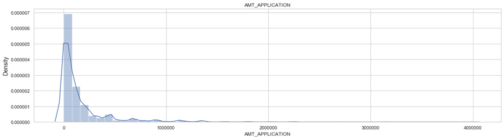

```python
plotHistogram(dfPrevOne_num, 'AMT_APPLICATION')
```

#### Analysis of Number of children for the client

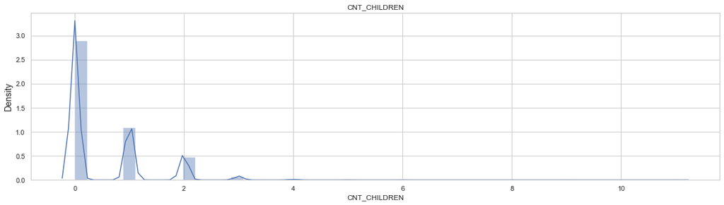

```python
plotHistogram(dfPrevOne_num, 'CNT_CHILDREN')
```

**Findings:** Here we can observe that the highest frequency of children for the client is Zero followed by one

#### Analysis of Credit Amount of Loan for the previous application

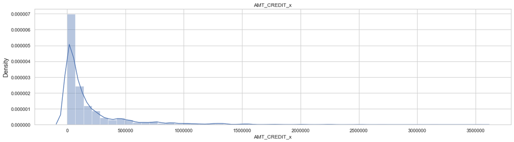

```python
plotHistogram(dfPrevOne_num, 'AMT_CREDIT_x')
```

#### Analysis of Income of the previous application

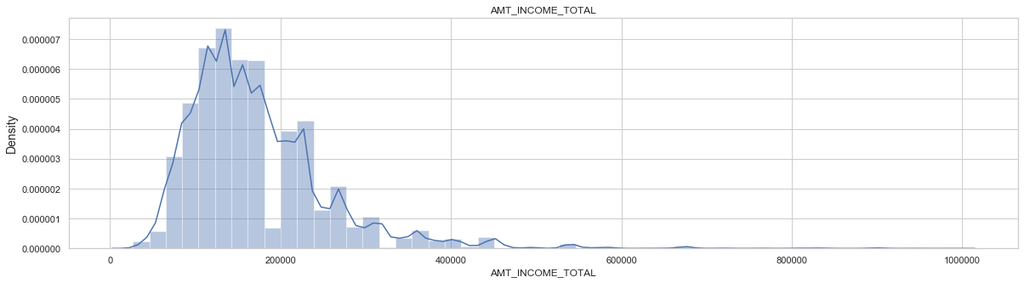

```python
plotHistogram(dfPrevOne_num, 'AMT_INCOME_TOTAL')
```

#### Analysis of Goods price of previous application

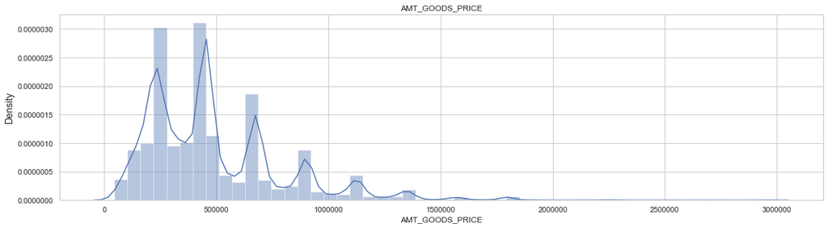

```python
plotHistogram(dfPrevOne_num, 'AMT_GOODS_PRICE')
```

**Findings:** Here we can observe that highest frequency of Goods price is between Rs.390000 and Rs. 450000

#### Univariate Analysis for categorical variables

```python
## Subsetting data for finding categorical variables
dfPrevOne_cat = dfPrevOne.select_dtypes(include='object')
```

```python
dfPrevOne_cat.info()
```

```
<class 'pandas.core.frame.DataFrame'>
Int64Index: 122360 entries, 27 to 1670204
Data columns (total 26 columns):
NAME_CONTRACT_TYPE_x            122360 non-null object
WEEKDAY_APPR_PROCESS_START_x    122360 non-null object
FLAG_LAST_APPL_PER_CONTRACT     122360 non-null object
NAME_CASH_LOAN_PURPOSE          122360 non-null object
NAME_CONTRACT_STATUS            122360 non-null object
NAME_PAYMENT_TYPE               122360 non-null object
CODE_REJECT_REASON              122360 non-null object
NAME_CLIENT_TYPE                122360 non-null object
NAME_GOODS_CATEGORY             122360 non-null object
NAME_PORTFOLIO                  122360 non-null object
NAME_PRODUCT_TYPE               122360 non-null object
CHANNEL_TYPE                    122360 non-null object
NAME_SELLER_INDUSTRY            122360 non-null object
NAME_YIELD_GROUP                122360 non-null object
PRODUCT_COMBINATION             122297 non-null object
NAME_CONTRACT_TYPE_y            122360 non-null object
CODE_GENDER                     122360 non-null object
FLAG_OWN_CAR                    122360 non-null object
FLAG_OWN_REALTY                 122360 non-null object
NAME_TYPE_SUITE                 122078 non-null object
NAME_INCOME_TYPE                122360 non-null object
NAME_EDUCATION_TYPE             122360 non-null object
NAME_FAMILY_STATUS              122360 non-null object
NAME_HOUSING_TYPE               122360 non-null object
WEEKDAY_APPR_PROCESS_START_y    122360 non-null object
ORGANIZATION_TYPE               122360 non-null object
dtypes: object(26)
memory usage: 25.2+ MB
```

```python
# Imputing the categorical values with mode
dfPrevOne_cat.fillna(dfPrevOne_cat.mode(), inplace=True)
```

```python
# Defining a function to view the distribution of the categorical variables
def plotFrequencyTable(df, catColName):
    '''
    This function is used to plot the frequency table of the specified categorical variable
    @df (dataframe) - Dataframe for which frequency table is to be plotted
    @catColName (string) - Column name for which frequency table is to be plotted
    '''
    sns.countplot(x=catColName, data=df)
    plt.title(catColName)
    plt.xticks(rotation = 90)
    plt.show();
```

#### Analysis of Client Income Type

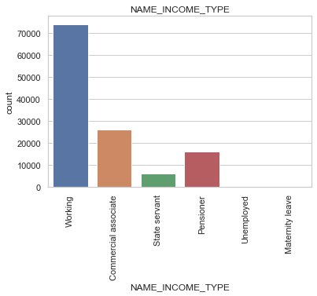

```python
plotFrequencyTable(dfPrevOne_cat,'NAME_INCOME_TYPE')
```

**Findings:** Here we can observe that most of the clients are working followed by Commercial associates

#### Analysis of Client Education Level

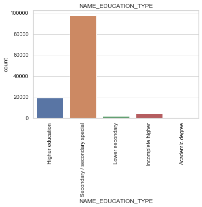

```python
plotFrequencyTable(dfPrevOne_cat,'NAME_EDUCATION_TYPE')
```

**Findings:** Here we can observe that most of the clients completed Secondary / Secondary special followed by Higher Education

#### Analysis of Client Housing Type

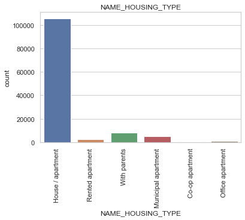

```python
plotFrequencyTable(dfPrevOne_cat,'NAME_HOUSING_TYPE')
```

**Findings:** Here we can observe that most of the clients stay in House/Apartments of their own followed by that of clients living with their parents

#### Analysis of Client Family Status

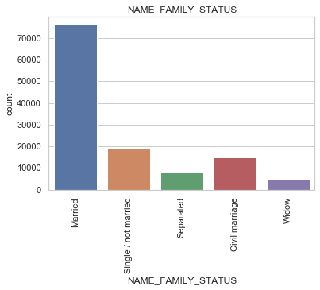

```python
plotFrequencyTable(dfPrevOne_cat,'NAME_FAMILY_STATUS')
```

**Findings:** Here we can observe that most of the clients are married followed by single/not married status and those who followed Civil marriage

#### Analysis of Client Accompaniment status

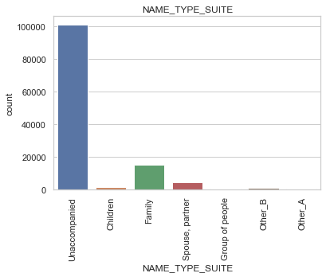

```python
plotFrequencyTable(dfPrevOne_cat,'NAME_TYPE_SUITE')
```

**Findings:** Here we can observe that most of the clients are unaccompanied when applying for loan followed by accompaniment by family

### Univariate Analysis on previous data where 'TARGET' = 0

#### Univariate Analysis for numerical variables

```python
# Sense check of data
dfPrevZero.head()
```

|  | SK_ID_PREV | SK_ID_CURR | NAME_CONTRACT_TYPE_x | AMT_APPLICATION | AMT_CREDIT_x | WEEKDAY_APPR_PROCESS_START_x | HOUR_APPR_PROCESS_START_x | FLAG_LAST_APPL_PER_CONTRACT | NFLAG_LAST_APPL_IN_DAY | NAME_CASH_LOAN_PURPOSE | NAME_CONTRACT_STATUS | DAYS_DECISION | NAME_PAYMENT_TYPE | CODE_REJECT_REASON | NAME_CLIENT_TYPE | NAME_GOODS_CATEGORY | NAME_PORTFOLIO | NAME_PRODUCT_TYPE | CHANNEL_TYPE | SELLERPLACE_AREA | NAME_SELLER_INDUSTRY | NAME_YIELD_GROUP | PRODUCT_COMBINATION | TARGET | NAME_CONTRACT_TYPE_y | CODE_GENDER | FLAG_OWN_CAR | FLAG_OWN_REALTY | CNT_CHILDREN | … |
| --- | --- | --- | --- | --- | --- | --- | --- | --- | --- | --- | --- | --- | --- | --- | --- | --- | --- | --- | --- | --- | --- | --- | --- | --- | --- | --- | --- | --- | --- | --- |
| 0 | 2030495 | 271877 | Consumer loans | 17145.0 | 17145.0 | SATURDAY | 15 | Y | 1 | XAP | Approved | -73 | Cash through the bank | XAP | Repeater | Mobile | POS | XNA | Country-wide | 35 | Connectivity | middle | POS mobile with interest | 0.0 | Cash loans | F | N | Y | 1.0 | … |
| 1 | 2802425 | 108129 | Cash loans | 607500.0 | 679671.0 | THURSDAY | 11 | Y | 1 | XNA | Approved | -164 | XNA | XAP | Repeater | XNA | Cash | x-sell | Contact center | -1 | XNA | low_action | Cash X-Sell: low | 0.0 | Revolving loans | F | N | N | 0.0 | … |
| 2 | 2523466 | 122040 | Cash loans | 112500.0 | 136444.5 | TUESDAY | 11 | Y | 1 | XNA | Approved | -301 | Cash through the bank | XAP | Repeater | XNA | Cash | x-sell | Credit and cash offices | -1 | XNA | high | Cash X-Sell: high | 0.0 | Cash loans | F | N | Y | 3.0 | … |
| 3 | 2819243 | 176158 | Cash loans | 450000.0 | 470790.0 | MONDAY | 7 | Y | 1 | XNA | Approved | -512 | Cash through the bank | XAP | Repeater | XNA | Cash | x-sell | Credit and cash offices | -1 | XNA | middle | Cash X-Sell: middle | 0.0 | Cash loans | M | Y | Y | 0.0 | … |
| 4 | 1784265 | 202054 | Cash loans | 337500.0 | 404055.0 | THURSDAY | 9 | Y | 1 | Repairs | Refused | -781 | Cash through the bank | HC | Repeater | XNA | Cash | walk-in | Credit and cash offices | -1 | XNA | high | Cash Street: high | 0.0 | Cash loans | F | N | N | 1.0 | … |

```python
# Subsetting the numerical columns from dfOne
numerics = ['int16', 'int32', 'int64', 'float16', 'float32', 'float64']
dfPrevZero_num = dfPrevZero.select_dtypes(include=numerics)
```

```python
# Imputing the numeric values with median values
dfPrevZero_num.fillna(dfPrevZero_num.median(), inplace=True)
```

```python
# TO understand the proper spread of the data, we add filters to remove the skew
dfPrevZero_num = dfPrevZero_num[dfPrevZero_num['DAYS_EMPLOYED'] < 300000]
dfPrevZero_num = dfPrevZero_num[dfPrevZero_num['AMT_INCOME_TOTAL'] < 1000000]
```

```python
# Function to plot histogram for numerical, univariate analysis
def plotHistogram(df, colName):
    '''
    This function is used to set the style of the plot, name the graph and plot the distribution for the specified column

    Inputs:
    @df (dataframe) - The dataframe for which histograms are to be plotted
    @colName (string) - The numeric column for which histograms is to be plotted

    Output:
    Titles distribution plot of specified colName
    '''
    sns.set(style="whitegrid")
    plt.figure(figsize=(20,5))
    plt.title(colName)
    plt.ylabel('Density', fontsize=14)
    sns.distplot(df[colName], kde=True)#, fit=stats.gamma)
```

**Note:** Here the y-axis represents the frequency density for each of the bins such that the area under the curve is equal to 1.

#### Analysis of Credit asked for the previous application

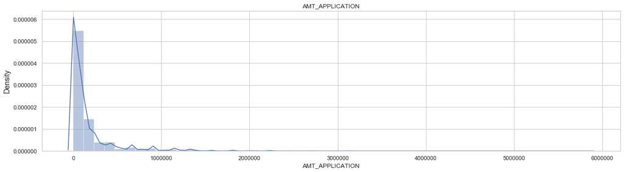

```python
plotHistogram(dfPrevZero_num, 'AMT_APPLICATION')
```

#### Analysis of Number of children for the client

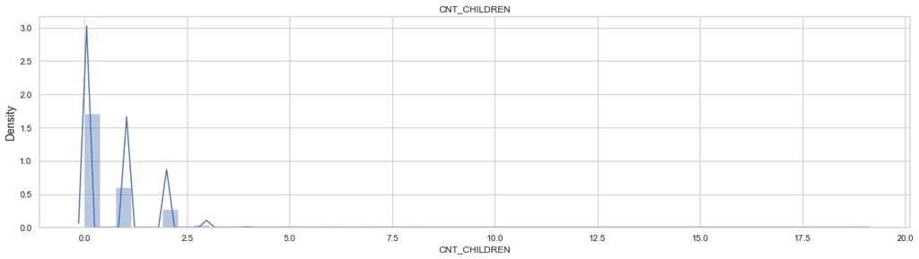

```python
plotHistogram(dfPrevZero_num, 'CNT_CHILDREN')
```

**Findings:** Here we can observe that the highest frequency of children for the client is Zero followed by one

#### Analysis of Credit Amount of Loan for the previous application

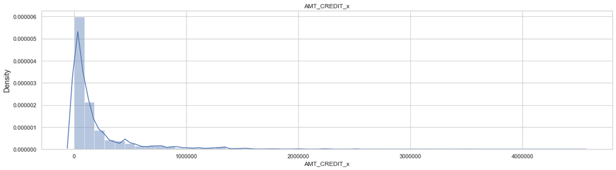

```python
plotHistogram(dfPrevZero_num, 'AMT_CREDIT_x')
```

#### Analysis of Income of the previous application

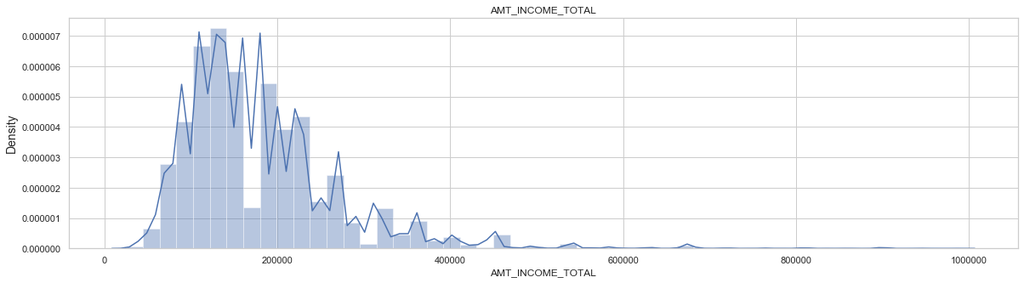

```python
plotHistogram(dfPrevZero_num, 'AMT_INCOME_TOTAL')
```

#### Analysis of Goods price of previous application

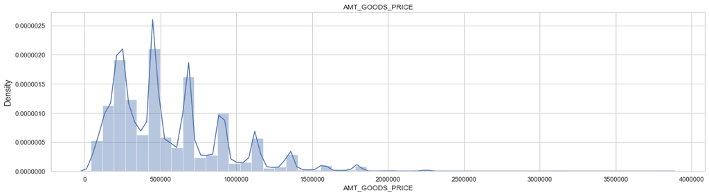

```python
plotHistogram(dfPrevZero_num, 'AMT_GOODS_PRICE')
```

**Findings:** Here we can observe that highest frequency of Goods price is between Rs.450000 and Rs.500000

#### Univariate Analysis for categorical variables

```python
## Subsetting data for finding categorical variables
dfPrevZero_cat = dfPrevZero.select_dtypes(include='object')
```

```python
dfPrevZero_cat.info()
```

```
<class 'pandas.core.frame.DataFrame'>
Int64Index: 1291341 entries, 0 to 1670213
Data columns (total 26 columns):
NAME_CONTRACT_TYPE_x            1291341 non-null object
WEEKDAY_APPR_PROCESS_START_x    1291341 non-null object
FLAG_LAST_APPL_PER_CONTRACT     1291341 non-null object
NAME_CASH_LOAN_PURPOSE          1291341 non-null object
NAME_CONTRACT_STATUS            1291341 non-null object
NAME_PAYMENT_TYPE               1291341 non-null object
CODE_REJECT_REASON              1291341 non-null object
NAME_CLIENT_TYPE                1291341 non-null object
NAME_GOODS_CATEGORY             1291341 non-null object
NAME_PORTFOLIO                  1291341 non-null object
NAME_PRODUCT_TYPE               1291341 non-null object
CHANNEL_TYPE                    1291341 non-null object
NAME_SELLER_INDUSTRY            1291341 non-null object
NAME_YIELD_GROUP                1291341 non-null object
PRODUCT_COMBINATION             1291091 non-null object
NAME_CONTRACT_TYPE_y            1291341 non-null object
CODE_GENDER                     1291341 non-null object
FLAG_OWN_CAR                    1291341 non-null object
FLAG_OWN_REALTY                 1291341 non-null object
NAME_TYPE_SUITE                 1288097 non-null object
NAME_INCOME_TYPE                1291341 non-null object
NAME_EDUCATION_TYPE             1291341 non-null object
NAME_FAMILY_STATUS              1291341 non-null object
NAME_HOUSING_TYPE               1291341 non-null object
WEEKDAY_APPR_PROCESS_START_y    1291341 non-null object
ORGANIZATION_TYPE               1291341 non-null object
dtypes: object(26)
memory usage: 266.0+ MB
```

```python
# Imputing the categorical values with mode
dfPrevZero_cat.fillna(dfPrevZero_cat.mode(), inplace=True)
```

```python
# Defining a function to view the distribution of the categorical variables
def plotFrequencyTable(df, catColName):
    '''
    This function is used to plot the frequency table of the specified categorical variable
    @df (dataframe) - Dataframe for which frequency table is to be plotted
    @catColName (string) - Column name for which frequency table is to be plotted
    '''
    sns.countplot(x=catColName, data=df)
    plt.title(catColName)
    plt.xticks(rotation = 90)
    plt.show();
```

#### Analysis of Client Income Type

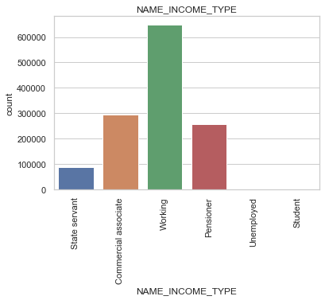

```python
plotFrequencyTable(dfPrevZero_cat,'NAME_INCOME_TYPE')
```

**Findings:** Here we can observe that most of the clients are working followed by Commercial associates and pensioners

#### Analysis of Client Education Level

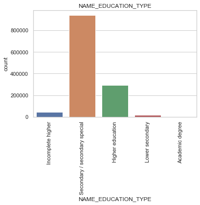

```python
plotFrequencyTable(dfPrevZero_cat,'NAME_EDUCATION_TYPE')
```

**Findings:** Here we can observe that most of the clients completed Secondary / Secondary special followed by Higher Education

#### Analysis of Client Housing Type

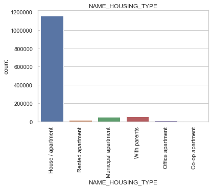

```python
plotFrequencyTable(dfPrevZero_cat,'NAME_HOUSING_TYPE')
```

**Findings:** Here we can observe that most of the clients stay in House/Apartments of their own followed by that of clients living with their parents

#### Analysis of Client Family Status

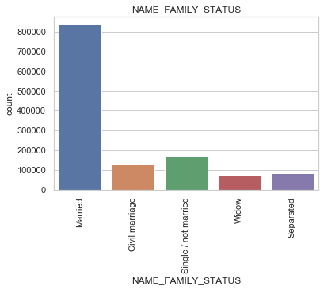

```python
plotFrequencyTable(dfPrevZero_cat,'NAME_FAMILY_STATUS')
```

**Findings:** Here we can observe that most of the clients are married followed by single/not married status and those who followed Civil marriage

#### Analysis of Client Accompaniment status

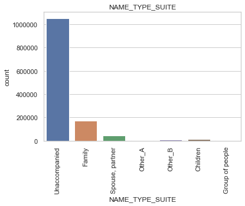

```python
plotFrequencyTable(dfPrevZero_cat,'NAME_TYPE_SUITE')
```

**Findings:** Here we can observe that most of the clients are unaccompanied when applying for loan followed by accompaniment by family

### Bivariate Analysis for previous application where 'TARGET' = 1

```python
# Defining a function to view bivariate analysis between categorical and continous variable
def plotCatNum(df, catColName, numColName):
    '''
    This function is used to plot to bivariate analysis between categorical and continous variable
    @df (dataframe) - Dataframe for which frequency table is to be plotted
    @catColName (string) - Column name of categorical variable for which frequency table is to be plotted
    @numColName (string) - Column name of continous variable for which frequency table is to be plotted
    '''
    sns.barplot(x=catColName,y=numColName,data=df)
    plt.title(catColName +' vs '+ numColName)
    plt.xticks(rotation = 90)
    plt.show();
```

```python
# Defining a function to view bivariate analysis between continous variables
def plotNumNum(df, num1ColName, num2ColName):
    '''
    This function is used to plot to bivariate analysis between two continous variable
    @df (dataframe) - Dataframe for which frequency table is to be plotted
    @catColName (string) - Column name of first continous variable for which frequency table is to be plotted
    @numColName (string) - Column name of second continous variable for which frequency table is to be plotted
    '''
    sns.set(style="whitegrid")
    plt.figure(figsize=(20,5))
    plt.title(num1ColName +' vs '+ num2ColName)
    plt.xticks(rotation = 90)
    sns.pointplot(x=num1ColName,y=num2ColName,data=df)
    plt.show();
```

#### Analysis of Education Type versus Loan Annuity for previous application

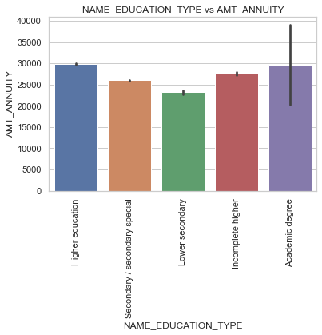

```python
plotCatNum(dfPrevOne,'NAME_EDUCATION_TYPE','AMT_ANNUITY')
```

#### Analysis of Family Status versus Loan Credit Amount for previous application

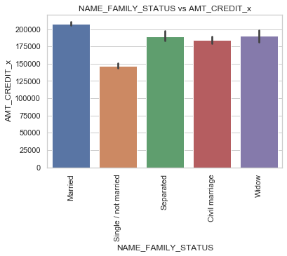

```python
plotCatNum(dfPrevOne,'NAME_FAMILY_STATUS','AMT_CREDIT_x')
```

#### Analysis of Income type versus Loan Credit Amount

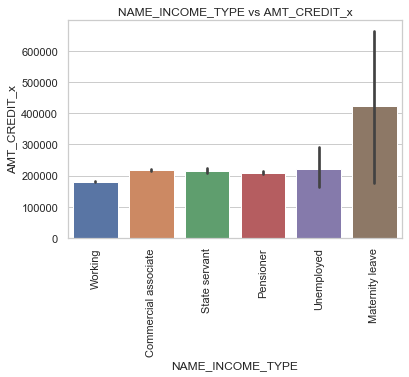

```python
plotCatNum(dfPrevOne,'NAME_INCOME_TYPE','AMT_CREDIT_x')
```

**Findings:** Here we can observe that most of the clients that are on maternity leave have the highest credit amount followed by Unemployed and State servant clients

#### Analysis of Housing status versus Loan Annuity

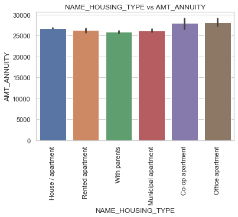

```python
plotCatNum(dfPrevOne,'NAME_HOUSING_TYPE','AMT_ANNUITY')
```

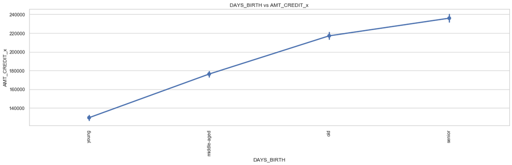

```python
plotNumNum(dfPrevOne,'DAYS_BIRTH','AMT_CREDIT_x')
```

**Findings:** Here we can observe that most of the clients that are Senior citizens has the highest credit loan amount followed by people of old category

### Bivariate Analysis for previous application where 'TARGET' = 0

```python
# Defining a function to view bivariate analysis between categorical and continous variable
def plotCatNum(df, catColName, numColName):
    '''
    This function is used to plot to bivariate analysis between categorical and continous variable
    @df (dataframe) - Dataframe for which frequency table is to be plotted
    @catColName (string) - Column name of categorical variable for which frequency table is to be plotted
    @numColName (string) - Column name of continous variable for which frequency table is to be plotted
    '''
    sns.barplot(x=catColName,y=numColName,data=df)
    plt.title(catColName +' vs '+ numColName)
    plt.xticks(rotation = 90)
    plt.show();
```

```python
# Defining a function to view bivariate analysis between continous variables
def plotNumNum(df, num1ColName, num2ColName):
    '''
    This function is used to plot to bivariate analysis between two continous variable
    @df (dataframe) - Dataframe for which frequency table is to be plotted
    @catColName (string) - Column name of first continous variable for which frequency table is to be plotted
    @numColName (string) - Column name of second continous variable for which frequency table is to be plotted
    '''
    sns.set(style="whitegrid")
    plt.figure(figsize=(20,5))
    plt.title(num1ColName +' vs '+ num2ColName)
    plt.xticks(rotation = 90)
    sns.pointplot(x=num1ColName,y=num2ColName,data=df)
    plt.show();
```

#### Analysis of Education Type versus Loan Annuity

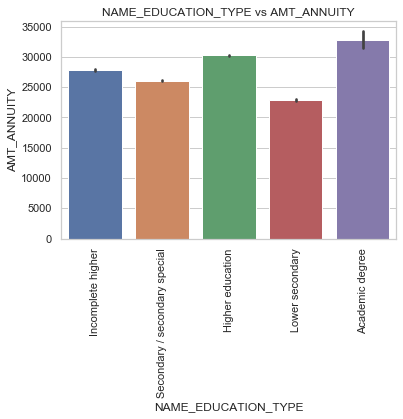

```python
plotCatNum(dfPrevZero,'NAME_EDUCATION_TYPE','AMT_ANNUITY')
```

**Findings:** Here we can observe that most of the clients with Academic Degree has the highest mean amount of loan annuity followed by clients that completed Higher education

#### Analysis of Family Status versus Loan Credit Amount

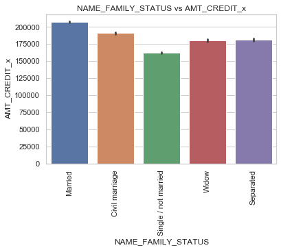

```python
plotCatNum(dfPrevZero,'NAME_FAMILY_STATUS','AMT_CREDIT_x')
```

#### Analysis of Income type versus Loan Credit Amount

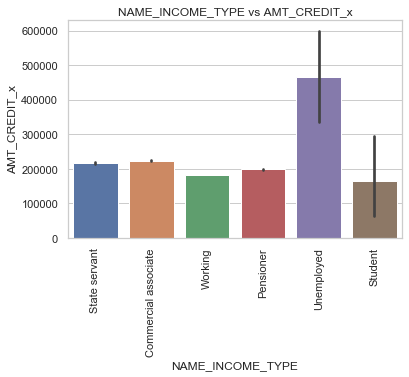

```python
plotCatNum(dfPrevZero,'NAME_INCOME_TYPE','AMT_CREDIT_x')
```

**Findings:** Here we can observe that most of the clients that are unemployed have the highest credit amount followed by Commercial associates and State servant clients

#### Analysis of Housing status versus Loan Annuity

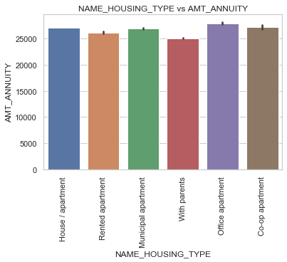

```python
plotCatNum(dfPrevZero,'NAME_HOUSING_TYPE','AMT_ANNUITY')
```

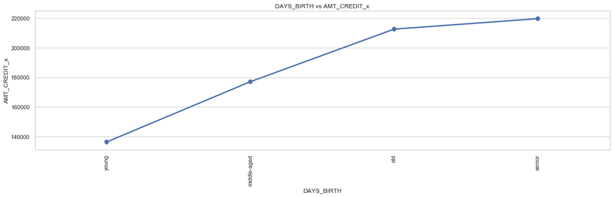

```python
plotNumNum(dfPrevZero,'DAYS_BIRTH','AMT_CREDIT_x')
```

**Findings:** Here we can observe that most of the clients that are Senior citizens has the highest credit loan amount followed by people of old category

# Inferences From Exploratory Data Analysis

**1.** Overwhelming majority of credit applicants with risk involved are young working clients that earn 1-2 lakhs per month and have experience of 1.5 to 2 years, risk analysis should target this age group  
**2.** Majority of the applicants request for Credit between 5-6 lakhs for goods prices worth approximately 5 lakhs. These applicants are likely to default  
**3.** Most of the applicants that leads to credit default have loan annuity between Rs.25000-30000.  
**4.** Defaulters are applicants that completely higher secondary education, own a house and are married. We can conclude that experience of owning capital can still lead to loan defaults  
**5.** Applicants that are unaccompanied during application process overwhelming shows the possibility of defaulting. Risk analysis should be more focused among this group  
**6.** Applicants that are likely to pay the loan amount earn comparatively the same amount as those who default but these applicants are likely to have more job experience  
**7.** Applicants that pay the loans on time apply for lesser credit loan between Rs.200000 - Rs 350000 compared to the defaulters  
**8.** Credit loan amount of applicants in other cases are more inline with the price of the goods than that of defaulters  
**9.** Majority of applicants in non-defaulters group are educated, married and owns a house or an apartment  
**10.** Among the applicants having diffulcy paying the loan amounts, a significant portion of those on maternity leaves have high loan annuity amounts  
**11.** Applicants that complete an academic degree and high annuity amount are more likely to default. This maybe due to preexisting loans that the applicant may have paid off in the past.  
**12.** Senior Citizens and applicants of old-age group have higher loan amount and are more likely to default  
**13.** Married applicants generally have the highest load credit amount and are more likely to belong to non-defaulters group  
**14.** A large number of applicants of young age group have lower credit amount and show promising signs of being a non-defaulter. By targeting these sectors through marketing, higher revenue can be generated  
**15.** Comparing the previous application and current application data, most of the applicants apply for higher amount of loan in the current period and thus more likely to default  
**16.** There is no significant jump in the salary of defaulters between the current and previous application although they submit for relatively higher amount of loan. Applicants that apply for more loan without salary jump is a red flag  
**17.** Applicants with one or more children are more likely to pay the loan than applicants with no children. Defaulters also tend to not report the number of family members  
**18.** Comparing previous and current application, we can infer that the unemployed customers that recently procure a job are more likely to pay the loans on time  
**19.** Applicants that move from Rented apartments to their own house/apartments between applications are more likely to be a non-defaulter  
**20.** There is no different in trend for defaulters that belong to senior or old age group between current and previous applications

# Conclusion

- This case study aims to identify patterns which indicate if a client has difficulty paying their instalments which may be used for taking actions such as denying the loan, reducing the amount of loan, lending (to risky applicants) at a higher interest rate, etc. We aim to understand the driving factors behind loan defaults for different types of applicants.
- Analysis was conducted on the prospective clients based on the their current as well as previous application data. Recommendations and insights were provided for the same.

**End note:** Thank you so much for taking the time to read this long, comprehensive notebook.

I hope you learnt and enjoyed our thorough analysis of all the intricacies of the largest dataset we have seen (yet!). It was a very difficult, but, great learning experience to understand how data scientists do exploratory data analysis. :)